# Support Vector Machines

Data Science and Predictive Machine Learning

## Packages used in this lecture

```r
library(MASS)     # for the cats data
library(magrittr) # pipes
library(dplyr)    # data manipulation
library(caret)    # flexible machine learning
library(kernlab)  # for SVM's
library(e1071)    # also for SVM's
library(DT)       # interactive tables
set.seed(123)     # for reproducibility
```

## So far

We have learned the following techniques

- linear regression
- logistic regression
- ridge regression
- lasso regression
- the elastic net

## Data

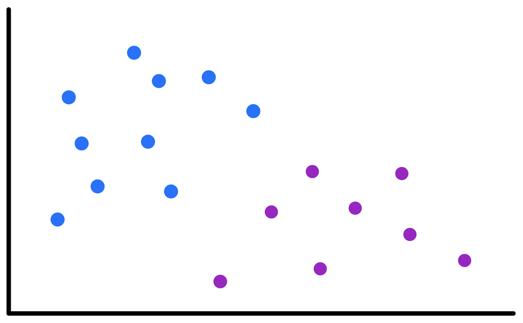

Our data has two classifications that are perfectly seperable by a hyperplane

## Hyperplanes

A hyperplane is a subspace whose dimension is one less than that of its ambient space.  
Hyperplanes divide a \(p\)-dimensional space into two distinct parts

[figure not shown]

[image source](https://miro.medium.com/max/600/0*iDZMC0LsciIANcYv.gif)

## For our data

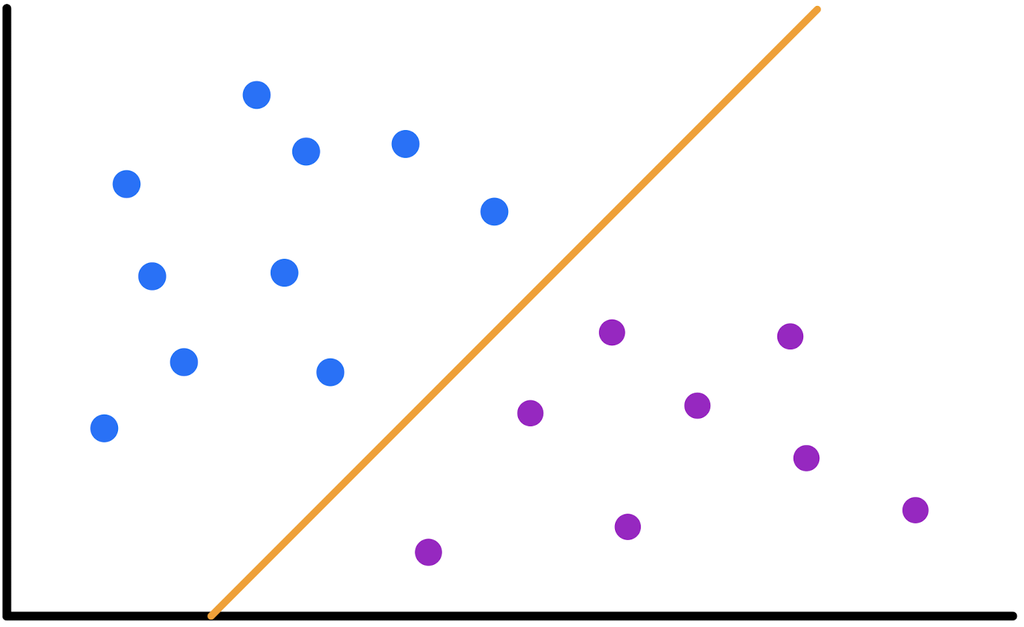

The aim for this lecture is to find the hyperplane that seperates the space into two parts.  
We will explore multiple ways of doing so

## But there is a problem

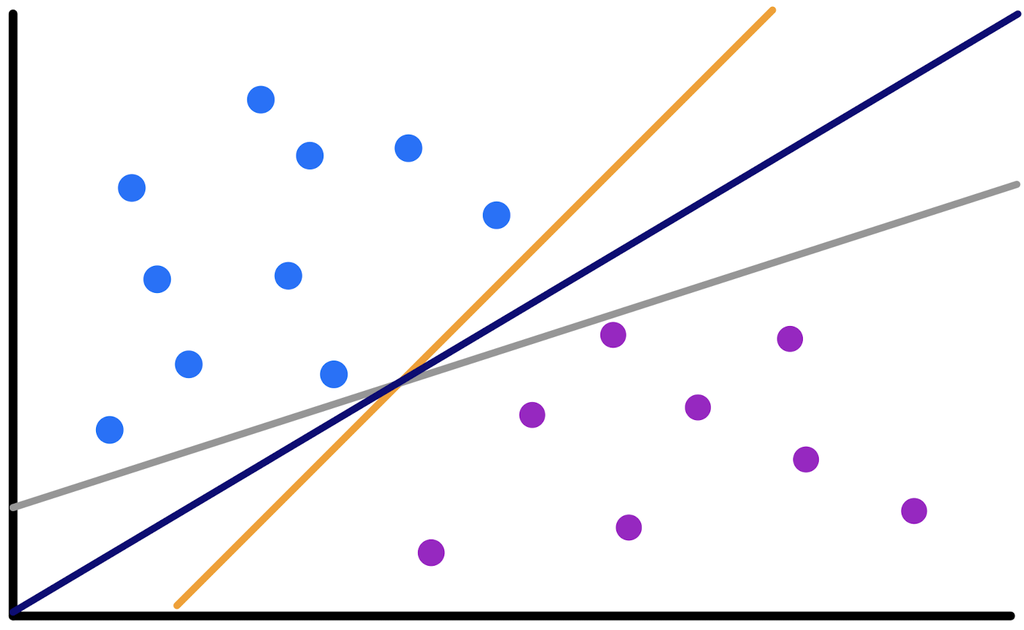

When data are perfectly seperable, there are infinite hyperplanes that seperate the space

## Maximal Margin Classifier

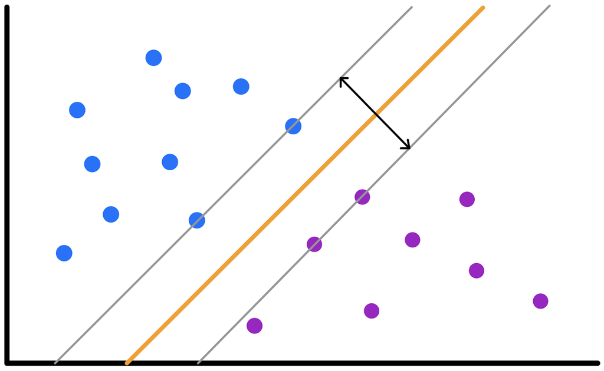

The chosen hyperplane maximizes the margins (i.e. the perpendicular distance from the hyperplane)  
The observations that fall on the margins are called the *support vectors*

## Maximal Margin Classifier

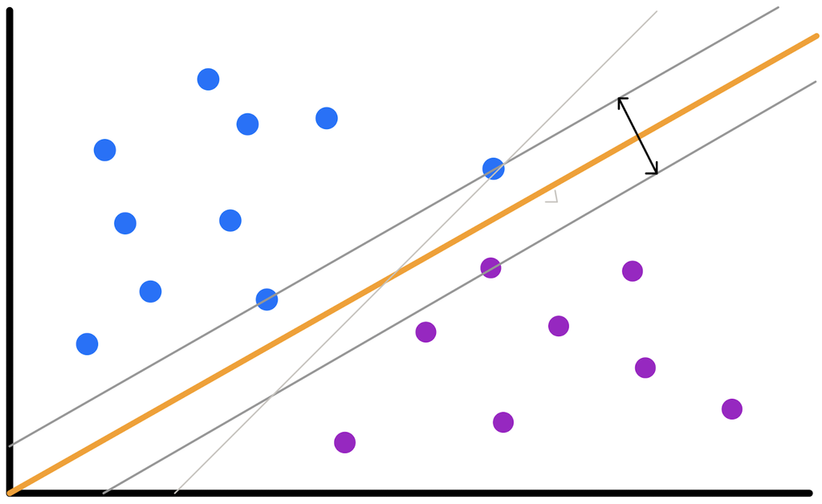

The maximal margin classifier suffers from a problem: it is highly dependent on the support vectors.  
Shifting, removing or adding even a single observation may lead to a dramatic change in the maximal margin hyperplane.

## Inseperable classes

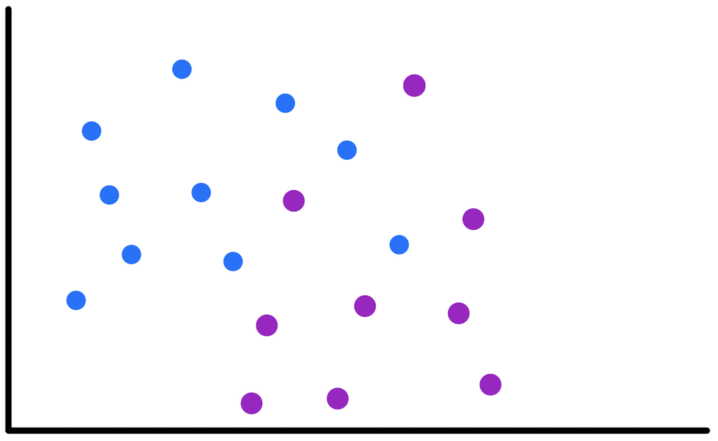

The maximal margin classifier is not suitable when classes are not perfectly seperable by a straight line  
In that case some room for error (Cost) needs to be allowed

## So far

**The maximal margin classifier** creates a hyperplane that maximizes the margins towards the support vectors

- It works if and only if classes are perfectly seperable
- It is highly sensitive to individual observations
- It is a so-called **hard classifier**

## Support vector classifier

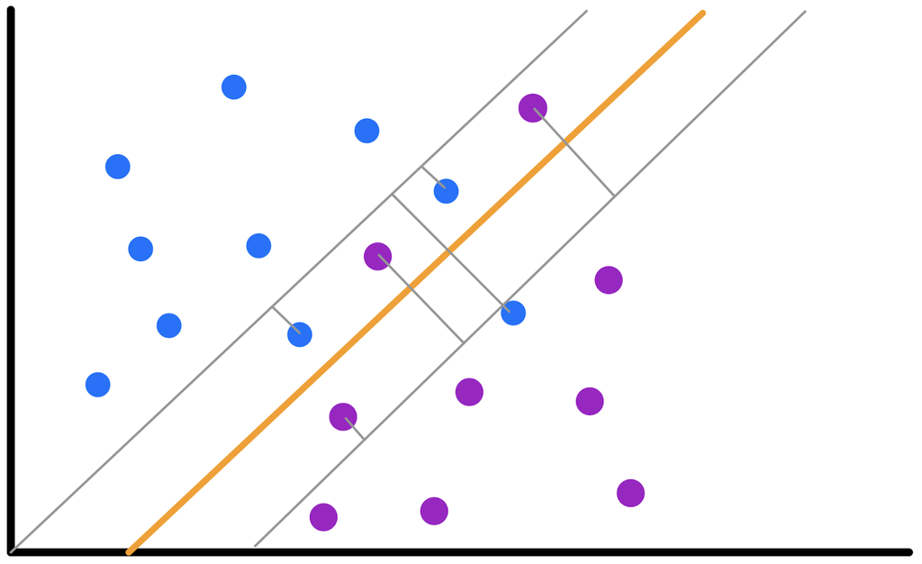

With the support vector classifier we allow for two errors: Observations may be incorrectly classified and observations may be on the wrong side of the margin.

## How does it work?

- When \(\varepsilon_i = 0\) then the \(i\)th observation is on the correct side of the margin.
- When \(\varepsilon_i > 0\) then the \(i\)th observation is on the wrong side of the margin.
- When \(\varepsilon_i > 1\) then the \(i\)th observation is on the wrong side of the hyperplane.

You can imagine that the wider we choose the margins, the higher the sum of the \(\varepsilon_i\)’s.  
To bound the sum of the \(\varepsilon_i\)’s we need a tuning parameter \(C\).

- \(C\) determines the number and severity of the violations to the margin (and to the hyperplane) that we will tolerate.
- If there is no room for violations to the margin, then it must be the case that \(\varepsilon_1 = \dots = \varepsilon_n = 0\). In that case \(C\) is large.

## Choosing \(C\)

\(C\) is a tuning parameter and needs to be chosen.

- When \(C\) is small, margins will be wide. With wider margins come many support vectors and more misclassified observations.
- When \(C\) is large , margins will be narrow. With narrower margins come fewer support vectors and less misclassified values.

Just like with every technique so far it holds that lowering \(C\) may prevent overfitting. This may yield better performance on the test set.  
We can again use validation techniques to find the value for \(C\) for which we minimize test error.  
[A good demo to play around with](https://cs.stanford.edu/~karpathy/svmjs/demo/)

## Non-linear seperability

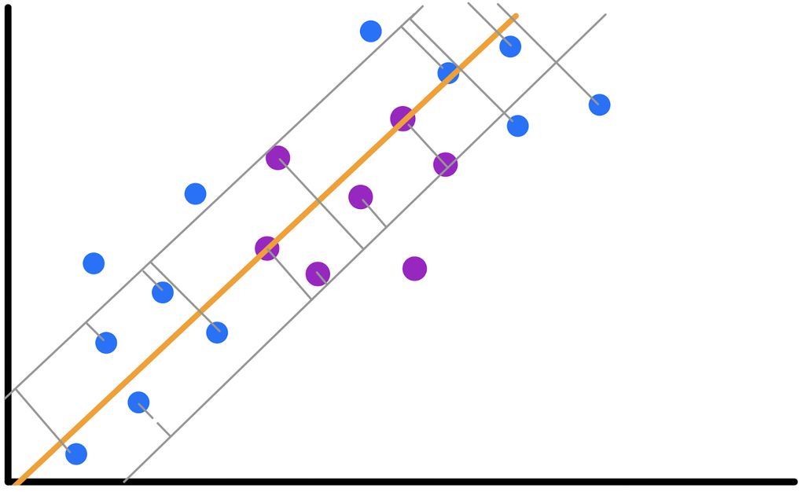

The support vector classifier is a linear classifier: It can not classify non-linearly seperable data.

## So far

**The maximal margin classifier** creates a hyperplane that maximizes the margins towards the support vectors

- It works if and only if classes are perfectly seperable
- It is highly sensitive to individual observations
- It is a so-called **hard classifier**

**The support vector classifier** creates a hyperplane that maximizes the margins towards the support vectors

- It works if and only if classes are linearly seperable
- It is not sensitive to individual observations
- It is a so-called **soft classifier**
- Use \(C\) to optimize for the margins: the distance the decision boundaries have from the hyperplane.

## Support vector machine

The **support vector machine** extends the support vectors classifier by using *kernels* to create non-linear decision boundaries.

Through the *kernel trick* it is possible to map the inputs in the original (i.e. lower dimensional space) and returns the dot product of the transformed vectors in the higher dimensional space.

It uses a *kernel function*. The most used are:

- linear kernel
- polynomial kernel
- radial kernel

If you want to read more about kernels, [this link](https://towardsdatascience.com/the-kernel-trick-c98cdbcaeb3f) provides some nice easy explanation

## Linear kernel

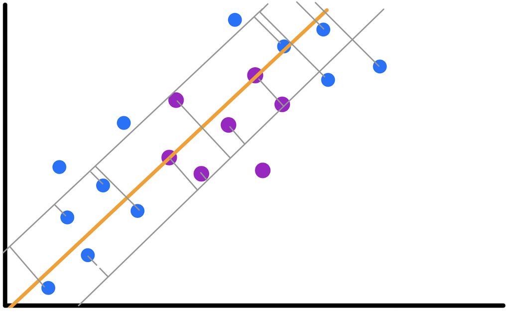

## Polynomial kernel

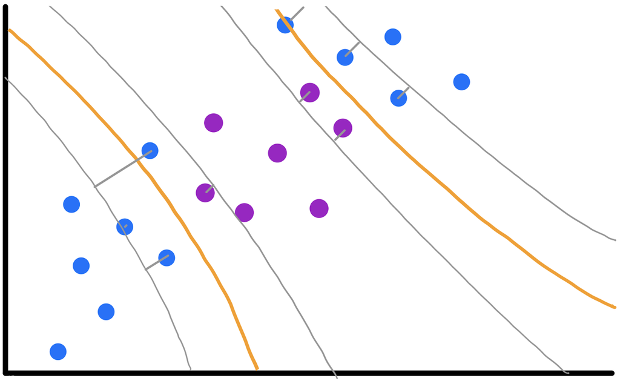

With the polynomial kernel we need to optimize over the polynomial degree, \(C\) and the scale (variance) \(\gamma\).

## Radial basis function kernel

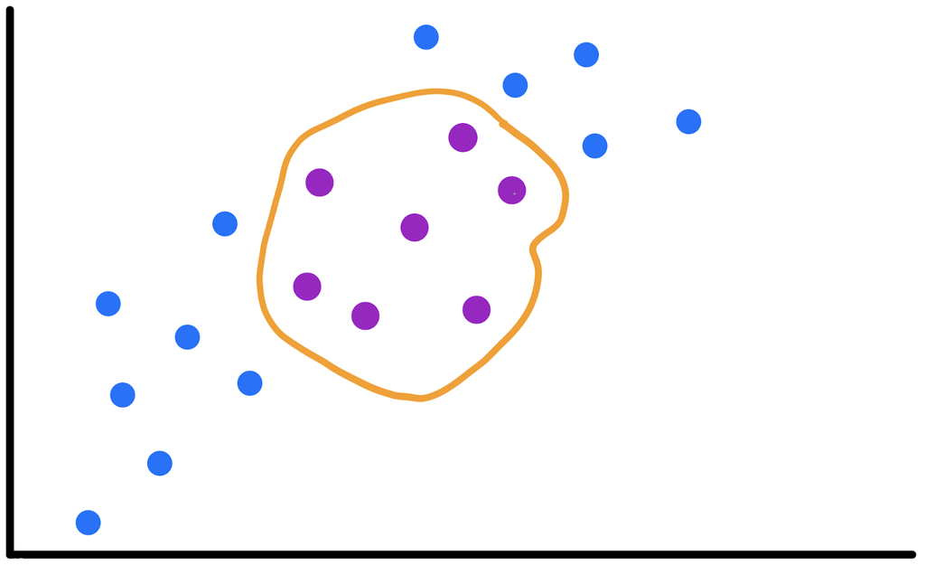

With the radial kernel there is another optimizable parameter \(\gamma\).

## Optimal \(\gamma\)

We can view \(\gamma\) as the inverse of the radius of influence of samples that are selected by the model as support vectors.

- the RBF kernel uses a Gaussian function
- low \(\gamma\) defines a Gaussian function with high variance: similarity is easier to realize between two points
- High \(\gamma\) defines a Gaussian function with low variance: similarity is harder to realize between two points - points need to have actual proximity.

Like always, \(\gamma\) can be optimized by test/train validation.

## Simple example

```r
head(cats)
```

```
##   Sex Bwt Hwt
## 1   F 2.0 7.0
## 2   F 2.0 7.4
## 3   F 2.0 9.5
## 4   F 2.1 7.2
## 5   F 2.1 7.3
## 6   F 2.1 7.6
```

```r
svm.cats <- svm(Sex ~ ., data = cats, kernel = "linear", cost = 1, scale = TRUE)
```

## Output

```r
svm.cats
```

```
##
## Call:
## svm(formula = Sex ~ ., data = cats, kernel = "linear", cost = 1,
##     scale = TRUE)
##
##
## Parameters:
##    SVM-Type:  C-classification
##  SVM-Kernel:  linear
##        cost:  1
##
## Number of Support Vectors:  78
```

## Plot

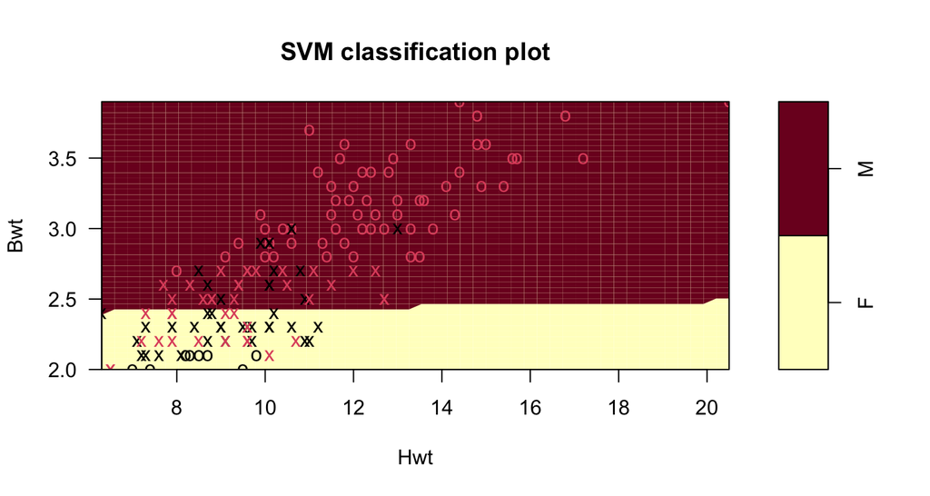

```r
plot(svm.cats, cats)
```

## Plot

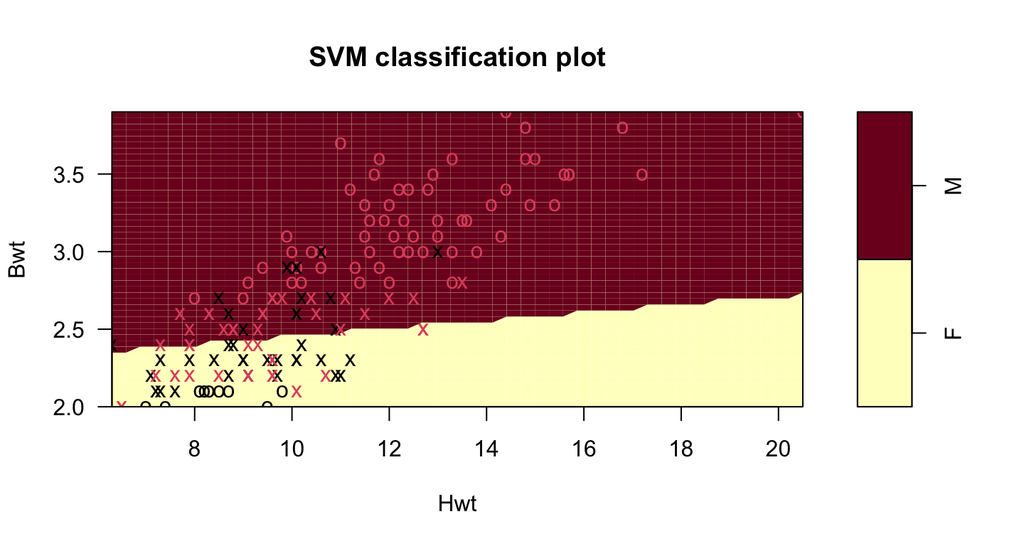

```r
svm.cats <- svm(Sex ~ ., data = cats, kernel = "linear", cost = 4, scale = TRUE)
plot(svm.cats, cats)
```

## with `caret` and crossvalidation

```r
train_control <- trainControl(method="repeatedcv", number=10, repeats=3)
svm.cats <- train(Sex ~.,
                  data = cats,
                  method = "svmLinear",
                  trControl = train_control,
                  preProcess = c("center","scale"))
```

## Output from caret

```r
svm.cats
```

```
## Support Vector Machines with Linear Kernel
##
## 144 samples
##   2 predictor
##   2 classes: 'F', 'M'
##
## Pre-processing: centered (2), scaled (2)
## Resampling: Cross-Validated (10 fold, repeated 3 times)
## Summary of sample sizes: 129, 129, 130, 130, 130, 130, ...
## Resampling results:
##
##   Accuracy   Kappa
##   0.7829182  0.5082337
##
## Tuning parameter 'C' was held constant at a value of 1
```

Parameter \(C\) is kept constant by default.

## Optimizing for \(C\)

```r
svm.cats <- train(Sex ~.,
                  data = cats,
                  method = "svmLinear",
                  trControl = trainControl(method="repeatedcv", number=10, repeats=3),
                  preProcess = c("center","scale"),
                  tuneGrid = expand.grid(C = seq(0.1, 10, length = 50)))
```

## Optimal C

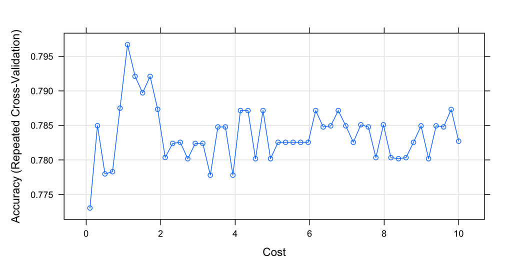

```r
plot(svm.cats)
```

## Plot

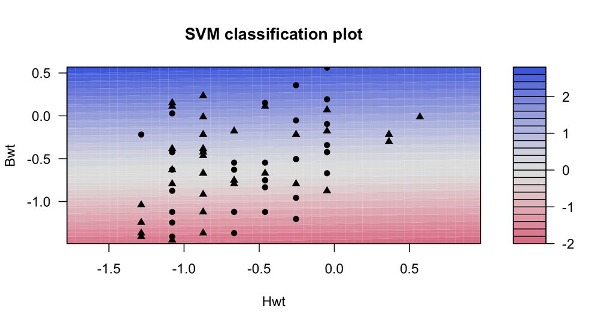

```r
kernlab::plot(svm.cats$finalModel)
```

## Radial Kernel

```r
svm.cats <- train(Sex ~.,
                  data = cats,
                  method = "svmRadial",
                  trControl = trainControl(method="repeatedcv", number=10, repeats=3),
                  preProcess = c("center","scale"),
                  tuneGrid = expand.grid(C = seq(0.1, 5, by = .1),
                                         sigma = seq(0.5, 5, by = .5)))
```

|  | C | sigma | Accuracy | Kappa | AccuracySD | KappaSD |
| --- | --- | --- | --- | --- | --- | --- |
| 1 | 0.1 | 0.5 | 0.674236874236874 | 0.019283819922989 | 0.043741670562205 | 0.1125580272135 |
| 11 | 0.2 | 0.5 | 0.762625152625153 | 0.439456960342632 | 0.0793201218033966 | 0.210448922741813 |
| 21 | 0.3 | 0.5 | 0.776141636141636 | 0.484563202561935 | 0.0772039797513233 | 0.198254654256286 |
| 31 | 0.4 | 0.5 | 0.778522588522588 | 0.488561977984859 | 0.0824057355152047 | 0.208518806682722 |
| 41 | 0.5 | 0.5 | 0.79026862026862 | 0.515958098553565 | 0.0882653465887356 | 0.220838090812839 |
| 51 | 0.6 | 0.5 | 0.783284493284493 | 0.499596272001369 | 0.0847936709329472 | 0.214043028595056 |
| 61 | 0.7 | 0.5 | 0.781062271062271 | 0.490949778178524 | 0.0771006179372216 | 0.198104584802615 |
| 71 | 0.8 | 0.5 | 0.781221001221001 | 0.49274125644059 | 0.0828727516933998 | 0.20940507094745 |
| 81 | 0.9 | 0.5 | 0.788571428571429 | 0.507041193507828 | 0.0761689396403563 | 0.203116634179272 |
| 91 | 1 | 0.5 | 0.788571428571429 | 0.507041193507828 | 0.0761689396403563 | 0.203116634179272 |

[output cut: 490 more lines]

## Optimal C and \(\gamma\)

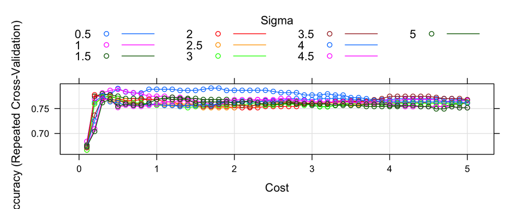

```r
plot(svm.cats)
```

```r
svm.cats$bestTune
```

```
##     sigma   C
## 161   0.5 1.7
```

## Plot

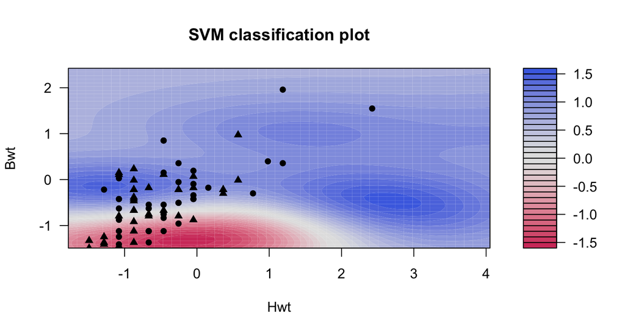

```r
kernlab::plot(svm.cats$finalModel)
```

## Performance

```r
pred <- predict(svm.cats)
postResample(pred, cats$Sex)
```

```
##  Accuracy     Kappa
## 0.7986111 0.5394795
```

```r
confusionMatrix(pred, cats$Sex)$table
```

```
##           Reference
## Prediction  F  M
##          F 32 14
##          M 15 83
```